# Predicting Dominant Macronutrients in Foods

## 1. Problem Definition

The goal of this project is to investigate whether machine learning can predict whether a food is protein-dominant, carbohydrate-dominant, or fat-dominant based on its nutritional characteristics.

The target variable is the **dominant macronutrient**, which will have three possible categories: protein, carbohydrates, or fat. This makes the project a **multiclass classification problem**.

Understanding the nutritional characteristics associated with different types of foods can be useful for people interested in nutrition and food composition. This project will explore whether nutritional characteristics such as fiber, sodium, and calories can be used to distinguish between foods with different dominant macronutrients.

```python
import pandas as pd
import numpy as np
import matplotlib.pyplot as plt
```

```python
food = pd.read_csv("food.csv")
food_nutrient = pd.read_csv("food_nutrient.csv")
nutrient = pd.read_csv("nutrient.csv")
```

```python
print("Food shape:", food.shape)
print("Food nutrient shape:", food_nutrient.shape)
print("Nutrient shape:", nutrient.shape)
```

```
Food shape: (87990, 5)
Food nutrient shape: (170469, 11)
Nutrient shape: (477, 5)
```

```python
print("FOOD COLUMNS:")
print(food.columns.tolist())

print("\nFOOD_NUTRIENT COLUMNS:")
print(food_nutrient.columns.tolist())

print("\nNUTRIENT COLUMNS:")
print(nutrient.columns.tolist())
```

```
FOOD COLUMNS:
['fdc_id', 'data_type', 'description', 'food_category_id', 'publication_date']

FOOD_NUTRIENT COLUMNS:
['id', 'fdc_id', 'nutrient_id', 'amount', 'data_points', 'derivation_id', 'min', 'max', 'median', 'footnote', 'min_year_acquired']

NUTRIENT COLUMNS:
['id', 'name', 'unit_name', 'nutrient_nbr', 'rank']
```

```python
print(food["data_type"].value_counts())
```

```
data_type
sub_sample_food             75055
market_acquisition           7577
sample_food                  4079
agricultural_acquisition      810
foundation_food               469
Name: count, dtype: int64
```

```python
foundation_foods = food[food["data_type"] == "foundation_food"].copy()

print("Number of Foundation Foods:", foundation_foods.shape[0])
foundation_foods.head()
```

```
Number of Foundation Foods: 469
```

|  | fdc_id | data_type | description | food_category_id | publication_date |
| --- | --- | --- | --- | --- | --- |
| 651 | 321358 | foundation_food | Hummus, commercial | 16.0 | 2019-04-01 |
| 652 | 321359 | foundation_food | Milk, reduced fat, fluid, 2% milkfat, with add... | 1.0 | 2019-04-01 |
| 653 | 321360 | foundation_food | Tomatoes, grape, raw | 11.0 | 2019-04-01 |
| 798 | 321505 | foundation_food | Salt, table, iodized | 2.0 | 2019-04-01 |
| 904 | 321611 | foundation_food | Beans, snap, green, canned, regular pack, drai... | 11.0 | 2019-04-01 |

### Selecting Foundation Foods

For this project, I focused on Foundation Foods rather than using every food in the dataset. Foundation Foods provide detailed nutritional information for basic foods and ingredients, which makes them useful for comparing nutritional characteristics. Limiting the analysis to this group also creates a more focused dataset for building the machine learning models.

After filtering the dataset, 469 Foundation Foods remained for the analysis.

### Identifying Nutrients

The nutrient dataset contains many different nutrient measurements and IDs. I searched for the nutrients relevant to this analysis to identify the correct nutrient IDs for protein, carbohydrates, fat, fiber, sodium, sugar, and calories.

```python
search_terms = ["protein", "carbohydrate", "fat", "fiber", "sugar", "sodium", "energy"]

for term in search_terms:
    print(f"\n--- {term.upper()} ---")
    display(
        nutrient[
            nutrient["name"].str.contains(term, case=False, na=False)
        ][["id", "name", "unit_name"]]
    )
```

```
--- PROTEIN ---
```

|  | id | name | unit_name |
| --- | --- | --- | --- |
| 4 | 1003 | Protein | G |
| 54 | 1053 | Adjusted Protein | G |

```
--- CARBOHYDRATE ---
```

|  | id | name | unit_name |
| --- | --- | --- | --- |
| 6 | 1005 | Carbohydrate, by difference | G |
| 51 | 1050 | Carbohydrate, by summation | G |
| 73 | 1072 | Carbohydrate, other | G |
| 450 | 2039 | Carbohydrates | G |

```
--- FAT ---
```

|  | id | name | unit_name |
| --- | --- | --- | --- |
| 5 | 1004 | Total lipid (fat) | G |
| 50 | 1049 | Solids, non-fat | G |
| 86 | 1085 | Total fat (NLEA) | G |
| 258 | 1257 | Fatty acids, total trans | G |
| 259 | 1258 | Fatty acids, total saturated | G |
| 291 | 1291 | Fatty acids, other than 607-615, 617-621, 624-... | G |
| 292 | 1292 | Fatty acids, total monounsaturated | G |
| 293 | 1293 | Fatty acids, total polyunsaturated | G |
| 318 | 1318 | Fatty acids, saturated, other | G |
| 319 | 1319 | Fatty acids, monounsat., other | G |
| 320 | 1320 | Fatty acids, polyunsat., other | G |
| 326 | 1326 | Fatty acids, total sat., NLEA | G |
| 327 | 1327 | Fatty acids, total monounsat., NLEA | G |
| 328 | 1328 | Fatty acids, total polyunsat., NLEA | G |
| 329 | 1329 | Fatty acids, total trans-monoenoic | G |
| 330 | 1330 | Fatty acids, total trans-dienoic | G |
| 331 | 1331 | Fatty acids, total trans-polyenoic | G |

```
--- FIBER ---
```

|  | id | name | unit_name |
| --- | --- | --- | --- |
| 7 | 1006 | Fiber, crude (DO NOT USE - Archived) | G |
| 67 | 1066 | Fiber, neutral detergent (DO NOT USE - Archived) | G |
| 80 | 1079 | Fiber, total dietary | G |
| 83 | 1082 | Fiber, soluble | G |
| 85 | 1084 | Fiber, insoluble | G |
| 444 | 2033 | Total dietary fiber (AOAC 2011.25) | G |
| 445 | 2034 | Insoluble dietary fiber (IDF) | G |
| 446 | 2035 | Soluble dietary fiber (SDFP+SDFS) | G |
| 447 | 2036 | Soluble dietary fiber (SDFP) | G |
| 448 | 2037 | Soluble dietary fiber (SDFS) | G |
| 449 | 2038 | High Molecular Weight Dietary Fiber (HMWDF) | G |
| 473 | 2065 | Low Molecular Weight Dietary Fiber (LMWDF) | G |

```
--- SUGAR ---
```

|  | id | name | unit_name |
| --- | --- | --- | --- |
| 64 | 1063 | Sugars, Total | G |
| 68 | 1067 | Reducing sugars | G |
| 87 | 1086 | Total sugar alcohols | G |
| 236 | 1235 | Sugars, added | G |
| 237 | 1236 | Sugars, intrinsic | G |
| 415 | 2000 | Total Sugars | G |

```
--- SODIUM ---
```

|  | id | name | unit_name |
| --- | --- | --- | --- |
| 94 | 1093 | Sodium, Na | MG |

```
--- ENERGY ---
```

|  | id | name | unit_name |
| --- | --- | --- | --- |
| 0 | 2047 | Energy (Atwater General Factors) | KCAL |
| 1 | 2048 | Energy (Atwater Specific Factors) | KCAL |
| 9 | 1008 | Energy | KCAL |
| 63 | 1062 | Energy | kJ |

### Selecting Nutrient Measurements

Based on the nutrient search above, I selected the nutrient IDs for protein, carbohydrates, fat, fiber, sugar, sodium, and calories. These records were extracted from the food nutrient dataset so that each food could later be represented by its nutritional values.

```python
nutrient_ids = {
    1003: "protein",
    1005: "carbohydrates",
    1004: "fat",
    1079: "fiber",
    2000: "sugar",
    1093: "sodium",
    1008: "calories"
}

selected_nutrients = food_nutrient[
    food_nutrient["nutrient_id"].isin(nutrient_ids.keys())
].copy()

selected_nutrients["nutrient_name"] = selected_nutrients["nutrient_id"].map(nutrient_ids)

print("Number of nutrient records:", selected_nutrients.shape[0])
selected_nutrients.head(10)
```

```
Number of nutrient records: 13051
```

|  | id | fdc_id | nutrient_id | amount | data_points | derivation_id | min | max | median | footnote | min_year_acquired | nutrient_name |
| --- | --- | --- | --- | --- | --- | --- | --- | --- | --- | --- | --- | --- |
| 2 | 2201846 | 319877 | 1004 | 19.0 | 1.0 | 1.0 | NaN | NaN | NaN | NaN | NaN | fat |
| 8 | 2201854 | 319878 | 1093 | 446.0 | 1.0 | 1.0 | NaN | NaN | NaN | NaN | NaN | sodium |
| 16 | 2201859 | 319882 | 1004 | 18.7 | 1.0 | 1.0 | NaN | NaN | NaN | NaN | NaN | fat |
| 19 | 2201862 | 319884 | 1093 | 444.0 | 1.0 | 1.0 | NaN | NaN | NaN | NaN | NaN | sodium |
| 28 | 2201873 | 319892 | 1004 | 16.6 | 1.0 | 1.0 | NaN | NaN | NaN | NaN | NaN | fat |
| 31 | 2201880 | 319893 | 1093 | 387.0 | 1.0 | 1.0 | NaN | NaN | NaN | NaN | NaN | sodium |
| 43 | 2201886 | 319899 | 1004 | 19.1 | 1.0 | 1.0 | NaN | NaN | NaN | NaN | NaN | fat |
| 50 | 2201895 | 319900 | 1093 | 489.0 | 1.0 | 1.0 | NaN | NaN | NaN | NaN | NaN | sodium |
| 97 | 2201942 | 319908 | 1004 | 18.2 | 1.0 | 1.0 | NaN | NaN | NaN | NaN | NaN | fat |
| 107 | 2201953 | 319912 | 1093 | 428.0 | 1.0 | 1.0 | NaN | NaN | NaN | NaN | NaN | sodium |

### Reshaping and Combining the Data

The nutrient records are stored in a long format, where each nutrient measurement appears as a separate row. I reshaped the data so that each food has its own row and each nutrient has its own column.

I then combined these nutrient values with the Foundation Foods dataset using the food ID.

```python
nutrient_wide = selected_nutrients.pivot_table(
    index="fdc_id",
    columns="nutrient_name",
    values="amount",
    aggfunc="mean"
).reset_index()

print("Shape:", nutrient_wide.shape)
nutrient_wide.head(10)
```

```
Shape: (9755, 8)
```

| nutrient_name | fdc_id | calories | carbohydrates | fat | fiber | protein | sodium | sugar |
| --- | --- | --- | --- | --- | --- | --- | --- | --- |
| 0 | 319877 | NaN | NaN | 19.0 | NaN | NaN | NaN | NaN |
| 1 | 319878 | NaN | NaN | NaN | NaN | NaN | 446.0 | NaN |
| 2 | 319882 | NaN | NaN | 18.7 | NaN | NaN | NaN | NaN |
| 3 | 319884 | NaN | NaN | NaN | NaN | NaN | 444.0 | NaN |
| 4 | 319892 | NaN | NaN | 16.6 | NaN | NaN | NaN | NaN |
| 5 | 319893 | NaN | NaN | NaN | NaN | NaN | 387.0 | NaN |
| 6 | 319899 | NaN | NaN | 19.1 | NaN | NaN | NaN | NaN |
| 7 | 319900 | NaN | NaN | NaN | NaN | NaN | 489.0 | NaN |
| 8 | 319908 | NaN | NaN | 18.2 | NaN | NaN | NaN | NaN |
| 9 | 319912 | NaN | NaN | NaN | NaN | NaN | 428.0 | NaN |

```python
foundation_data = foundation_foods[
    ["fdc_id", "description", "food_category_id"]
].merge(
    nutrient_wide,
    on="fdc_id",
    how="left"
)

print("Shape:", foundation_data.shape)
foundation_data.head(10)
```

```
Shape: (469, 10)
```

|  | fdc_id | description | food_category_id | calories | carbohydrates | fat | fiber | protein | sodium | sugar |
| --- | --- | --- | --- | --- | --- | --- | --- | --- | --- | --- |
| 0 | 321358 | Hummus, commercial | 16.0 | 229.0 | 14.90 | 17.10 | 5.4 | 7.35 | 438.0 | NaN |
| 1 | 321359 | Milk, reduced fat, fluid, 2% milkfat, with add... | 1.0 | 50.0 | 4.91 | 1.90 | NaN | 3.35 | 39.0 | NaN |
| 2 | 321360 | Tomatoes, grape, raw | 11.0 | 27.0 | 5.51 | 0.63 | 2.1 | 0.83 | 6.0 | NaN |
| 3 | 321505 | Salt, table, iodized | 2.0 | NaN | NaN | NaN | NaN | NaN | 38700.0 | NaN |
| 4 | 321611 | Beans, snap, green, canned, regular pack, drai... | 11.0 | 21.0 | 4.11 | 0.39 | NaN | 1.04 | 282.0 | NaN |
| 5 | 321900 | Broccoli, raw | 11.0 | 32.0 | 6.29 | 0.34 | 2.4 | 2.57 | 36.0 | NaN |
| 6 | 322228 | Milk, lowfat, fluid, 1% milkfat, with added vi... | 1.0 | 43.0 | 5.19 | 0.95 | NaN | 3.38 | 39.0 | NaN |
| 7 | 322559 | Milk, nonfat, fluid, with added vitamin A and ... | 1.0 | 34.0 | 4.89 | 0.08 | NaN | 3.43 | 41.0 | NaN |
| 8 | 322892 | Milk, whole, 3.25% milkfat, with added vitamin D | 1.0 | 60.0 | 4.67 | 3.20 | NaN | 3.28 | 38.0 | NaN |
| 9 | 323121 | Frankfurter, beef, unheated | 7.0 | 314.0 | 2.89 | 28.00 | NaN | 11.70 | 872.0 | NaN |

### Checking for Missing Values

Before building the machine learning model, I checked how many nutrient values were missing from the Foundation Foods dataset. Some nutrients had substantially more missing data than others, especially sugar and calories.

Understanding the missing data is important because the machine learning models require complete values for the variables used during training.

```python
print("Missing values in each column:")
print(foundation_data.isnull().sum())

print("\nPercentage missing:")
print((foundation_data.isnull().mean() * 100).round(1))
```

```
Missing values in each column:
fdc_id                0
description           0
food_category_id      0
calories            334
carbohydrates        92
fat                  56
fiber               228
protein              44
sodium               66
sugar               464
dtype: int64

Percentage missing:
fdc_id               0.0
description          0.0
food_category_id     0.0
calories            71.2
carbohydrates       19.6
fat                 11.9
fiber               48.6
protein              9.4
sodium              14.1
sugar               98.9
dtype: float64
```

### Preparing Complete Macronutrient Data

To determine the dominant macronutrient of each food, the dataset needs values for protein, carbohydrates, and fat. Foods missing any of these three values were removed.

Out of 469 Foundation Foods, 377 had complete values for all three macronutrients and were kept for the analysis.

```python
macro_complete = foundation_data.dropna(
    subset=["protein", "carbohydrates", "fat"]
).copy()

print("Total Foundation Foods:", foundation_data.shape[0])
print("Foods with all 3 macros:", macro_complete.shape[0])
print("Foods removed:", foundation_data.shape[0] - macro_complete.shape[0])

macro_complete[["description", "protein", "carbohydrates", "fat"]].head(10)
```

```
Total Foundation Foods: 469
Foods with all 3 macros: 377
Foods removed: 92
```

|  | description | protein | carbohydrates | fat |
| --- | --- | --- | --- | --- |
| 0 | Hummus, commercial | 7.35 | 14.90 | 17.10 |
| 1 | Milk, reduced fat, fluid, 2% milkfat, with add... | 3.35 | 4.91 | 1.90 |
| 2 | Tomatoes, grape, raw | 0.83 | 5.51 | 0.63 |
| 4 | Beans, snap, green, canned, regular pack, drai... | 1.04 | 4.11 | 0.39 |
| 5 | Broccoli, raw | 2.57 | 6.29 | 0.34 |
| 6 | Milk, lowfat, fluid, 1% milkfat, with added vi... | 3.38 | 5.19 | 0.95 |
| 7 | Milk, nonfat, fluid, with added vitamin A and ... | 3.43 | 4.89 | 0.08 |
| 8 | Milk, whole, 3.25% milkfat, with added vitamin D | 3.28 | 4.67 | 3.20 |
| 9 | Frankfurter, beef, unheated | 11.70 | 2.89 | 28.00 |
| 10 | Nuts, almonds, dry roasted, with salt added | 20.40 | 16.20 | 57.80 |

```python
macro_complete["protein_calories"] = macro_complete["protein"] * 4
macro_complete["carb_calories"] = macro_complete["carbohydrates"] * 4
macro_complete["fat_calories"] = macro_complete["fat"] * 9

macro_complete["dominant_macronutrient"] = macro_complete[
    ["protein_calories", "carb_calories", "fat_calories"]
].idxmax(axis=1)

macro_complete["dominant_macronutrient"] = macro_complete[
    "dominant_macronutrient"
].replace({
    "protein_calories": "protein",
    "carb_calories": "carbohydrates",
    "fat_calories": "fat"
})

print(macro_complete["dominant_macronutrient"].value_counts())

macro_complete[
    ["description", "protein", "carbohydrates", "fat", "dominant_macronutrient"]
].head(10)
```

```
dominant_macronutrient
carbohydrates    221
fat               95
protein           61
Name: count, dtype: int64
```

|  | description | protein | carbohydrates | fat | dominant_macronutrient |
| --- | --- | --- | --- | --- | --- |
| 0 | Hummus, commercial | 7.35 | 14.90 | 17.10 | fat |
| 1 | Milk, reduced fat, fluid, 2% milkfat, with add... | 3.35 | 4.91 | 1.90 | carbohydrates |
| 2 | Tomatoes, grape, raw | 0.83 | 5.51 | 0.63 | carbohydrates |
| 4 | Beans, snap, green, canned, regular pack, drai... | 1.04 | 4.11 | 0.39 | carbohydrates |
| 5 | Broccoli, raw | 2.57 | 6.29 | 0.34 | carbohydrates |
| 6 | Milk, lowfat, fluid, 1% milkfat, with added vi... | 3.38 | 5.19 | 0.95 | carbohydrates |
| 7 | Milk, nonfat, fluid, with added vitamin A and ... | 3.43 | 4.89 | 0.08 | carbohydrates |
| 8 | Milk, whole, 3.25% milkfat, with added vitamin D | 3.28 | 4.67 | 3.20 | fat |
| 9 | Frankfurter, beef, unheated | 11.70 | 2.89 | 28.00 | fat |
| 10 | Nuts, almonds, dry roasted, with salt added | 20.40 | 16.20 | 57.80 | fat |

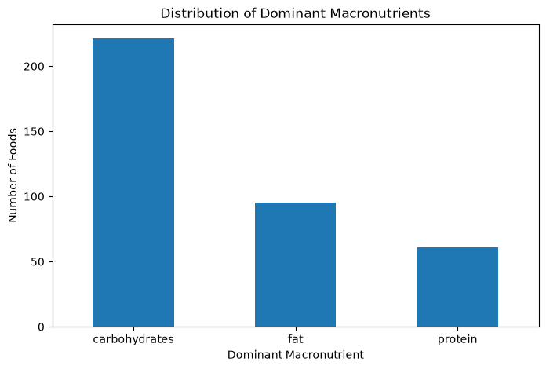

```python
class_counts = macro_complete["dominant_macronutrient"].value_counts()

plt.figure(figsize=(8, 5))
class_counts.plot(kind="bar")

plt.title("Distribution of Dominant Macronutrients")
plt.xlabel("Dominant Macronutrient")
plt.ylabel("Number of Foods")
plt.xticks(rotation=0)

plt.show()
```

### Target Distribution

The target distribution shows that the dataset is imbalanced. Carbohydrate-dominant foods are the largest class with 221 foods, followed by 95 fat-dominant foods and 61 protein-dominant foods.

Because carbohydrate-dominant foods are much more common, accuracy alone may not fully describe model performance. For this reason, I also evaluated the models using precision, recall, F1-score, and confusion matrices.

### Creating the Target Variable

The target variable for this project is the dominant macronutrient of each food. To determine this, I converted the grams of each macronutrient into calories. Protein and carbohydrates provide about 4 calories per gram, while fat provides about 9 calories per gram.

For each food, I compared the calories coming from protein, carbohydrates, and fat. Whichever macronutrient contributed the most calories was labeled as that food's dominant macronutrient.

This created three possible classes for the machine learning models: carbohydrates, fat, and protein.

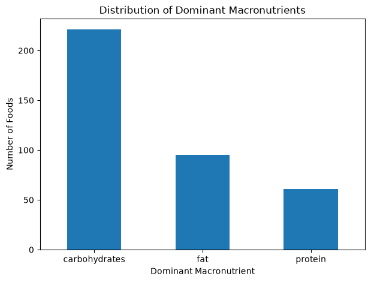

```python
class_counts = macro_complete["dominant_macronutrient"].value_counts()

plt.figure(figsize=(7, 5))
class_counts.plot(kind="bar")

plt.title("Distribution of Dominant Macronutrients")
plt.xlabel("Dominant Macronutrient")
plt.ylabel("Number of Foods")
plt.xticks(rotation=0)

plt.show()
```

### Dominant Macronutrient Distribution

The dataset contains more carbohydrate-dominant foods than fat- or protein-dominant foods. Of the 377 foods used in the analysis, 221 are carbohydrate-dominant, 95 are fat-dominant, and 61 are protein-dominant.

This shows that the target classes are not evenly distributed. Because of this imbalance, accuracy alone may not fully describe model performance, so additional measures such as precision, recall, F1-score, and confusion matrices will also be considered.

### Selecting Features and Avoiding Data Leakage

The features selected for the models are fiber, sodium, and calories. Protein, carbohydrates, and fat were not included as predictor variables because they were already used to create the dominant macronutrient target.

Including those variables as features would cause data leakage because the models would be given the same information that was used to determine the correct answer. By excluding them, the models must instead use other nutritional characteristics to predict the dominant macronutrient.

```python
features = ["fiber", "sodium", "calories"]

print("Missing values:")
print(macro_complete[features].isnull().sum())

print("\nAvailable rows if we require all 3 features:")
print(macro_complete[features].dropna().shape[0])
```

```
Missing values:
fiber       192
sodium        7
calories    242
dtype: int64

Available rows if we require all 3 features:
54
```

### Selecting Features for the Model

The initial features selected for the model were fiber, sodium, and calories. However, many foods were missing values for fiber and calories. Requiring every food to have all three features would reduce the dataset from 377 foods to only 54 foods.

To avoid losing most of the dataset, missing feature values will need to be handled before training the model.

```python
model_data = macro_complete.copy()

for column in ["fiber", "sodium", "calories"]:
    model_data[column] = model_data[column].fillna(
        model_data[column].median()
    )

print("Missing values after filling:")
print(model_data[["fiber", "sodium", "calories"]].isnull().sum())

print("\nNumber of foods:")
print(model_data.shape[0])
```

```
Missing values after filling:
fiber       0
sodium      0
calories    0
dtype: int64

Number of foods:
377
```

### Handling Missing Feature Values

Instead of removing foods with missing fiber, sodium, or calorie values, I filled the missing values using the median of each feature. This allowed all 377 foods with complete macronutrient information to remain in the dataset.

The median was used because it is less affected by unusually high or low values than the mean. After this step, there were no missing values in the three features used by the models.

```python
X = model_data[["fiber", "sodium", "calories"]]
y = model_data["dominant_macronutrient"]

print("Features:")
print(X.head())

print("\nTarget:")
print(y.head())

print("\nTarget counts:")
print(y.value_counts())
```

```
Features:
   fiber  sodium  calories
0  5.400   438.0     229.0
1  2.428    39.0      50.0
2  2.100     6.0      27.0
4  2.428   282.0      21.0
5  2.400    36.0      32.0

Target:
0              fat
1    carbohydrates
2    carbohydrates
4    carbohydrates
5    carbohydrates
Name: dominant_macronutrient, dtype: str

Target counts:
dominant_macronutrient
carbohydrates    221
fat               95
protein           61
Name: count, dtype: int64
```

```python
%pip install scikit-learn
```

```python
from sklearn.model_selection import train_test_split

X_train, X_test, y_train, y_test = train_test_split(
    X,
    y,
    test_size=0.2,
    random_state=42,
    stratify=y
)

print("Training foods:", X_train.shape[0])
print("Testing foods:", X_test.shape[0])
```

```
Training foods: 301
Testing foods: 76
```

### Baseline Model

Before evaluating the machine learning models, I created a baseline for comparison. Since carbohydrates are the most common dominant macronutrient in the dataset, the baseline model predicts carbohydrates for every food.

The machine learning models should perform better than this baseline to show that they are learning useful patterns from the nutritional features.

```python
from sklearn.dummy import DummyClassifier
from sklearn.metrics import accuracy_score

baseline_model = DummyClassifier(strategy="most_frequent")
baseline_model.fit(X_train, y_train)

baseline_pred = baseline_model.predict(X_test)
baseline_accuracy = accuracy_score(y_test, baseline_pred)

print("Baseline Accuracy:", round(baseline_accuracy * 100, 2), "%")
```

```
Baseline Accuracy: 59.21 %
```

### Baseline Results

The baseline model achieved an accuracy of 59.21% by always predicting the most common class, carbohydrates. This provides a minimum performance level for comparison.

Both machine learning models should achieve an accuracy higher than 59.21% to demonstrate that they are learning useful patterns from the nutritional features rather than simply predicting the most common class.

### Training the Decision Tree Model

A Decision Tree classifier was used as the first machine learning model. The model was trained using the training portion of the dataset and a maximum depth of 4 was used to keep the tree from becoming too complex.

The trained model was then used to predict the dominant macronutrient for foods in the testing set.

```python
from sklearn.tree import DecisionTreeClassifier

model = DecisionTreeClassifier(
    max_depth=4,
    random_state=42
)

model.fit(X_train, y_train)

print("Model trained successfully!")
```

```
Model trained successfully!
```

```python
from sklearn.metrics import accuracy_score

y_pred = model.predict(X_test)

accuracy = accuracy_score(y_test, y_pred)

print("Model Accuracy:", round(accuracy * 100, 2), "%")
```

```
Model Accuracy: 68.42 %
```

```python
from sklearn.metrics import classification_report

print(classification_report(y_test, y_pred))
```

```
               precision    recall  f1-score   support

carbohydrates       0.85      0.78      0.81        45
          fat       0.62      0.42      0.50        19
      protein       0.41      0.75      0.53        12

     accuracy                           0.68        76
    macro avg       0.63      0.65      0.61        76
 weighted avg       0.72      0.68      0.69        76
```

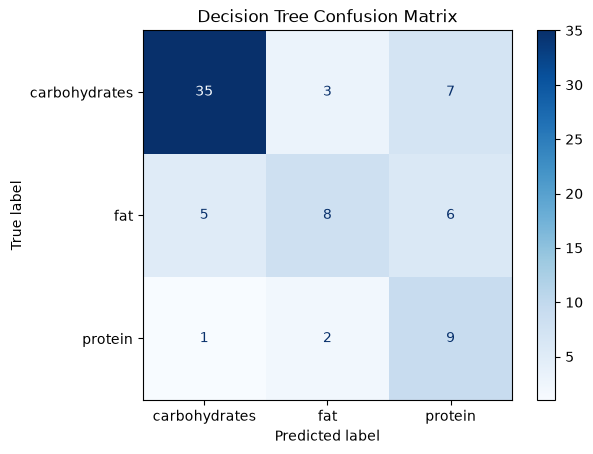

```python
from sklearn.metrics import confusion_matrix, ConfusionMatrixDisplay

ConfusionMatrixDisplay.from_predictions(
    y_test,
    y_pred,
    cmap="Blues"
)

plt.title("Decision Tree Confusion Matrix")
plt.show()
```

### Decision Tree Results

The Decision Tree achieved an accuracy of 68.42% on the testing data.

The confusion matrix shows that the model correctly classified 35 of the 45 carbohydrate-dominant foods, 8 of the 19 fat-dominant foods, and 9 of the 12 protein-dominant foods. The model performed best when identifying carbohydrate-dominant foods and had more difficulty identifying fat-dominant foods.

Overall, the Decision Tree was able to identify patterns in the nutritional data, but there is still room for improvement.

```
sodium      0.638318
calories    0.275878
fiber       0.085804
dtype: float64
```

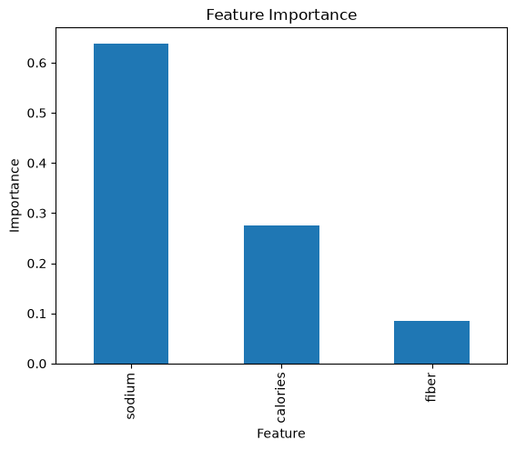

```python
feature_importance = pd.Series(
    model.feature_importances_,
    index=X.columns
).sort_values(ascending=False)

print(feature_importance)

feature_importance.plot(kind="bar")
plt.title("Feature Importance")
plt.xlabel("Feature")
plt.ylabel("Importance")
plt.show()
```

### Decision Tree Feature Importance

The feature importance results show that sodium was the most important feature for the Decision Tree, accounting for about 63.8% of the total importance. Calories were the second most important feature at about 27.6%, while fiber had the lowest importance at about 8.6%.

This suggests that sodium had the strongest influence on how the Decision Tree classified foods as carbohydrate-, fat-, or protein-dominant.

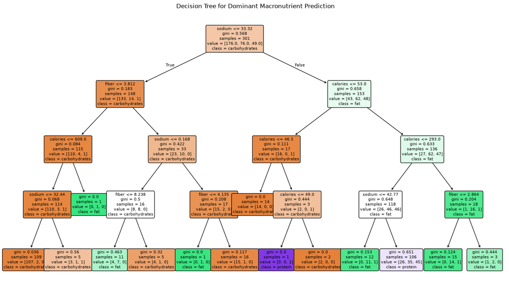

```python
from sklearn.tree import plot_tree

plt.figure(figsize=(18, 10))

plot_tree(
    model,
    feature_names=X.columns,
    class_names=model.classes_,
    filled=True,
    rounded=True,
    fontsize=8
)

plt.title("Decision Tree for Dominant Macronutrient Prediction")
plt.show()
```

### Decision Tree Visualization

The decision tree shows how the model uses sodium, fiber, and calorie values to classify each food. The model begins with sodium at the top of the tree and then follows different branches based on the nutritional values of each food.

Each path eventually leads to a prediction of carbohydrates, fat, or protein as the dominant macronutrient. The tree also helps visualize why sodium had the highest feature importance in the model.

## Model Results

The decision tree model achieved an accuracy of 68.42%, meaning that it correctly predicted the dominant macronutrient for about 68% of the foods in the test data.

The model performed best when identifying carbohydrate-dominant foods. It had more difficulty distinguishing fat- and protein-dominant foods.

The feature importance results showed that sodium was the most important predictor, followed by calories and fiber. The decision tree visualization also shows that sodium was used for the first split in the model.

Overall, the results show that nutritional characteristics can provide useful information for predicting whether a food is primarily dominated by carbohydrates, fat, or protein, although the model is not perfect.

## Random Forest Model

To see if the model's performance could be improved, I also trained a Random Forest classifier using the same training and testing data.

Random Forest combines predictions from multiple decision trees instead of relying on only one tree. I used 100 trees in the model and compared its accuracy to the original Decision Tree.

```python
from sklearn.ensemble import RandomForestClassifier

rf_model = RandomForestClassifier(
    n_estimators=100,
    random_state=42
)

rf_model.fit(X_train, y_train)

rf_pred = rf_model.predict(X_test)

rf_accuracy = accuracy_score(y_test, rf_pred)

print("Random Forest Accuracy:", round(rf_accuracy * 100, 2), "%")
print("Decision Tree Accuracy:", round(accuracy * 100, 2), "%")
```

```
Random Forest Accuracy: 76.32 %
Decision Tree Accuracy: 68.42 %
```

```python
print("Random Forest Classification Report:")
print(classification_report(y_test, rf_pred))
```

```
Random Forest Classification Report:
               precision    recall  f1-score   support

carbohydrates       0.84      0.91      0.87        45
          fat       0.67      0.63      0.65        19
      protein       0.56      0.42      0.48        12

     accuracy                           0.76        76
    macro avg       0.69      0.65      0.67        76
 weighted avg       0.75      0.76      0.75        76
```

### Random Forest Results

The Random Forest model performed well when identifying carbohydrate-dominant foods. It correctly identified 41 out of 45 carbohydrate-dominant foods.

The model had more difficulty identifying protein-dominant foods, correctly identifying 5 out of 12. Overall, the Random Forest achieved an accuracy of 76.32%, which was higher than the Decision Tree's accuracy of 68.42%.

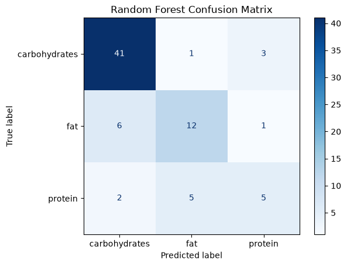

```python
from sklearn.metrics import ConfusionMatrixDisplay

ConfusionMatrixDisplay.from_predictions(
    y_test,
    rf_pred,
    cmap="Blues"
)

plt.title("Random Forest Confusion Matrix")
plt.show()
```

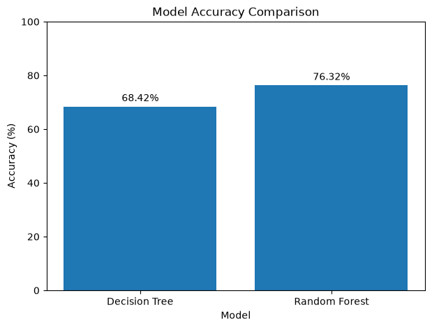

```python
models = ["Decision Tree", "Random Forest"]
accuracies = [accuracy * 100, rf_accuracy * 100]

plt.figure(figsize=(7, 5))
plt.bar(models, accuracies)

plt.title("Model Accuracy Comparison")
plt.xlabel("Model")
plt.ylabel("Accuracy (%)")
plt.ylim(0, 100)

for i, value in enumerate(accuracies):
    plt.text(i, value + 2, f"{value:.2f}%", ha="center")

plt.show()
```

## Model Comparison

The Random Forest model achieved an accuracy of 76.32%, compared with 68.42% for the Decision Tree and 59.21% for the baseline model. Both machine learning models performed better than the baseline, showing that they learned useful patterns from the nutritional features. The Random Forest improved accuracy by 7.90 percentage points compared with the Decision Tree. The Random Forest performed especially well when identifying carbohydrate-dominant foods. Fat-dominant foods were also predicted more accurately than with the Decision Tree, while protein-dominant foods remained the most difficult category to classify. Overall, the Random Forest performed better and was selected as the stronger model for this project.

```
Random Forest Feature Importance:
sodium      0.569154
fiber       0.226541
calories    0.204305
dtype: float64
```

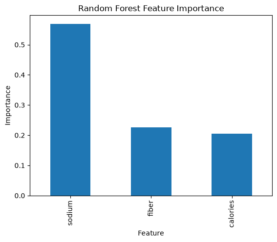

```python
rf_importance = pd.Series(
    rf_model.feature_importances_,
    index=X.columns
).sort_values(ascending=False)

print("Random Forest Feature Importance:")
print(rf_importance)

rf_importance.plot(kind="bar")
plt.title("Random Forest Feature Importance")
plt.xlabel("Feature")
plt.ylabel("Importance")
plt.show()
```

### Random Forest Feature Importance

The Random Forest model shows that sodium was the most important feature for predicting the dominant macronutrient, accounting for more than half of the total feature importance. Fiber and calories were also useful, but had much lower importance.

This suggests that sodium levels in the foods in this dataset contain useful information for distinguishing between foods dominated by carbohydrates, fat, or protein.

## Conclusion

The goal of this project was to determine whether nutritional information could be used to predict whether a food is primarily dominated by carbohydrates, fat, or protein. The baseline model achieved an accuracy of 59.21%, the Decision Tree achieved 68.42%, and the Random Forest achieved the highest accuracy at 76.32%. Since both machine learning models performed better than the baseline, the results suggest that the selected nutritional features contained useful information for predicting the dominant macronutrient. The Random Forest was the strongest model overall. It performed especially well when identifying carbohydrate-dominant foods, while protein-dominant foods remained the most difficult to classify. Sodium was the most important feature in the Random Forest, followed by fiber and calories. Overall, this project showed that nutritional characteristics can be used to predict a food's dominant macronutrient with reasonable accuracy, although the model still makes some incorrect predictions.